# IslandMapper Take-Home Assignment

# Question # 1

The Waterfall Railway is the suggested route for getting from The Beach to Island City. But during Monsoon season, many people living on the southern end of the beach say they prefer Banana Buses. By looking at the data, can you suggest why this might be?

# Answer # 1

The first thing to do is figure out the length of the beach. What's the walking distance from north to south end?

```python
import pandas as pd
import geopandas as gpd
from shapely.geometry import Point
import geopy.distance
```

```python
f = open("island_data/stops.txt", "r")
print(f.read())
f.close()
```

```
stop_id,stop_name,stop_lat,stop_lon
Stop_IslandCity,Island City Central Station,49.712802, -179.280571
Stop_BeachNorth,The Beach (North) Rail Station,49.493027,-178.975434
Stop_HauntedJungle,The Haunted Jungle,49.462797,179.866938
Stop_BambooCross,Bamboo Crossroads,49.433159,-179.115743
Stop_BeachSouth,The Beach (South) Bus Station,49.403503,-178.966984
```

```python
# distance between beach stations

south_beach = (49.40350, -178.96698)
north_beach = (49.49303, -178.97543)

miles = round(geopy.distance.geodesic(north_beach, south_beach).miles,1)
bike_minutes = round(miles * 5, 1)
minutes = round(miles * 20, 1)

print(f"North to South Beach: \n {miles} miles \n {minutes} minutes walking (not good) \n {bike_minutes} minutes cycling")
```

```
North to South Beach:
 6.2 miles
 124.0 minutes walking (not good)
 31.0 minutes cycling
```

## The distance between the north and south stations is a whopping 6 miles!

Say you are at the south station: The city-bound bus has a 10-minute, headway-based schedule, meaning you will wait an average of 5 minutes no matter what time you arrive. The rail service has fifteen-minute, schedule-based service, but any time-savings from scheduling pale in comparison to the walk. In ADDITION, the bus has better headways and travels just as fast as the railway. Just taking the bus will save you two hours if you're already at South Beach.

## IslandMapper should suggest the bus for almost everybody on the south half of the beach

### FROM SOUTH BEACH TO ISLAND CITY:

### On Bus: 20 Minutes

Walk: 0 Min

Wait: 5 Min (avg)

Transit: 15 Min

### Train plus Bike: 46 - 53.5 Minutes

Cycle: 31 Min

Wait: 0 min planned trip, 7.5 minutes for random arrival

Transit: 15 Min

### On Train: 2 Hours, 19-26.5 Minutes

Walk: 124 Min

Wait: 0 min planned trip, 7.5 minutes for random arrival

Transit: 15 Min

# Question # 2

Many people catching Banana Buses from the beach find themselves accidentally catching the wrong one and ending up in the Haunted Jungle instead. What could be improved in the data to help prevent this, and what specifically would you change?

# Answer # 2

The bus and IslandMapper app likely display roughly the same fields:

routes.route_short_name

trips.headsign

For example, it might read "WF1 - Island City"

Given the following Routes and Trips Tables:

```python
# Routes
f = open("island_data/routes.txt", "r")
print(f.read())
f.close()
```

```
route_id,agency_id,route_short_name,route_long_name,route_type
Waterfall1,WaterfallRailway,WF1,The Beach <-> Island City,2
BananaBus1,BananaBuses,Ban1,The Beach <-> Island City,3
BananaBus2,BananaBuses,Ban2,The Beach <-> The Haunted Jungle,3
```

```python
# trips
f = open("island_data/trips.txt", "r")
print(f.read())
f.close()
```

```
route_id,service_id,trip_id,trip_headsign
Waterfall1,Weekdays,Waterfall_0001,Island City
Waterfall1,Weekdays,Waterfall_0002,The Beach (North)
Waterfall1,Weekdays,Waterfall_0003,Island City
Waterfall1,Weekdays,Waterfall_0004,The Beach (North)
Waterfall1,Weekdays,Waterfall_0005,Island City
Waterfall1,Weekdays,Waterfall_0006,The Beach (North)
BananaBus1,Weekdays,Banana_Ban1_1001,Westbound
BananaBus1,Weekdays,Banana_Ban1_1002,Eastbound
BananaBus2,Weekdays,Banana_Ban2_1001,Westbound
BananaBus2,Weekdays,Banana_Ban2_1002,Eastbound
```

### We can determine that whether you are at South Beach or Bamboo Crossroads, The city-bound and jungle-bound buses, respectively, read

### "Ban1 - Westbound" vs "Ban2 - Westbound"

This is obviously a little too similar

From the front, both buses might even just say "WestBound" without the route name or ID- I'm sure this varies by agency- my local bus uses the headsign field for the full display name

### There are a few ways to go about this, but my personal preference is to rename "Eastbound/Westbound" designation to the name of the route terminus

```python
# UPDATE trips
# SET trip_headsign = "Island City"
# WHERE trip_id = "Banana_Ban1_1001";

# UPDATE trips
# SET trip_headsign = "Haunted Jungle"
# WHERE trip_id = "Banana_Ban2_1001";

# UPDATE trips
# SET trip_headsign = "South Beach"
# WHERE trip_id = "Banana_Ban1_1002";

# UPDATE trips
# SET trip_headsign = "South Beach"
# WHERE trip_id = "Banana_Ban2_1002";
```

Resulting in new displays which read:

## "Ban1 - Island City" vs "Ban2- Haunted Jungle"

# Question # 3

1. The GTFS file specifies Waterfall Railway and Banana Bus schedules in different ways. If you were standing in the middle of The Beach at 14:23, which would you be more likely to see first: a Waterfall Train or a Banana Bus? Explain why you think this, and why you may be wrong.

# Answer # 3

The Train Comes every 15 minutes on a schedule (at 2:00, 2:15, 2:30)- so you would expect to see the first train depart at 14:30, or in 7 Minutes.

The bus has headway-based scheduling. Both the BananaBus1 and BananaBus2 depart from South Beach every 10 minutes. This means a bus should depart the beach on average every five minutes, and the average amount of time you would have to wait to see a departure is two and a half minutes.

### You should expect a train at EXACTLY 14:30, and you would expect a bus, on average, at 14:25:30, or 4.5 minutes sooner than the train

Headway-based scheduling can have issues, namely bus-bunching.

This means wait-times, while on average about half of the headway, can exceed the headway, and there is no way to truly know when the next bus should come.

# Question # 4

A number of bug reports have come in about the IslandMapper app mysteriously crashing when people enter The Haunted Jungle. Except for ghosts, can you suggest what may be causing the crash by looking at the data and seeing if there's anything special about The Haunted Jungle?

# Answer # 4

## The Haunted Jungle is so far west that it's in the eastern hemisphere. The most common causes of bugs here are projection issues and inattention to datatypes.

Just to briefly demonstrate one of the ways that this frequently breaks mapping applications, the following code maps the stops without accounting for this projection issue.

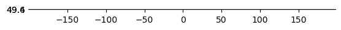

```python
stop_names = []
stop_ids = []
geometry = []
with open('island_data/stops.txt') as file:
    for line in file:
        stop_data = line.split(",")
        stop_id = stop_data[0]
        stop_name = stop_data[1]
        if stop_data[2].strip() != "stop_lat":
            latitude = float(stop_data[2].strip())
            longitude = float(stop_data[3].strip())
            stop_ids += [stop_id]
            stop_names += [stop_name]
            geometry += [Point(longitude, latitude)]
stops_dict = {"stop_name": stop_names, "stop_id": stop_ids, "geometry": geometry}
stops = gpd.GeoDataFrame(stops_dict, crs="EPSG:4326")
stops.plot()
```

Where this code maps the stops with a minor correction to chart the points correctly scaled to their relative distances apart

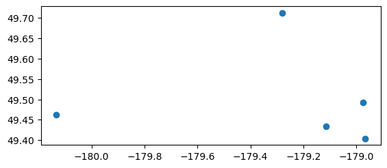

```python
stop_names = []
stop_ids = []
geometry = []
with open('island_data/stops.txt') as file:
    for line in file:
        stop_data = line.split(",")
        stop_id = stop_data[0]
        stop_name = stop_data[1]
        if stop_data[2].strip() != "stop_lat":
            latitude = float(stop_data[2].strip())
            longitude = float(stop_data[3].strip())

            # Here is the correction
            if longitude > 0:
                longitude = (-180) - (180.0 - longitude)

            stop_ids += [stop_id]
            stop_names += [stop_name]
            geometry += [Point(longitude, latitude)]
stops_dict = {"stop_name": stop_names, "stop_id": stop_ids, "geometry": geometry}
stops = gpd.GeoDataFrame(stops_dict, crs="EPSG:4326")
stops.plot()
```

## I look forward to meeting everybody!

## - Ben Carneiro - https://transit.observer

# Raw Data

```python
f = open("island_data/agency.txt", "r")
print(f.read())
f.close()
```

```
agency_id,agency_name,agency_url,agency_timezone
WaterfallRailway,The Waterfall Railway,https://citymapper.com/,America/Adak
BananaBuses,Banana Bus Company,https://citymapper.com/,America/Adak
```

```python
f = open("island_data/calendar.txt", "r")
print(f.read())
f.close()
```

```
service_id,monday,tuesday,wednesday,thursday,friday,saturday,sunday,start_date,end_date
Weekdays,1,1,1,1,1,0,0,20170101,20220101
Weekends,0,0,0,0,0,1,1,20170101,20220101
```

```python
f = open("island_data/routes.txt", "r")
print(f.read())
f.close()
```

```
route_id,agency_id,route_short_name,route_long_name,route_type
Waterfall1,WaterfallRailway,WF1,The Beach <-> Island City,2
BananaBus1,BananaBuses,Ban1,The Beach <-> Island City,3
BananaBus2,BananaBuses,Ban2,The Beach <-> The Haunted Jungle,3
```

```python
f = open("island_data/trips.txt", "r")
print(f.read())
f.close()
```

```
route_id,service_id,trip_id,trip_headsign
Waterfall1,Weekdays,Waterfall_0001,Island City
Waterfall1,Weekdays,Waterfall_0002,The Beach (North)
Waterfall1,Weekdays,Waterfall_0003,Island City
Waterfall1,Weekdays,Waterfall_0004,The Beach (North)
Waterfall1,Weekdays,Waterfall_0005,Island City
Waterfall1,Weekdays,Waterfall_0006,The Beach (North)
BananaBus1,Weekdays,Banana_Ban1_1001,Westbound
BananaBus1,Weekdays,Banana_Ban1_1002,Eastbound
BananaBus2,Weekdays,Banana_Ban2_1001,Westbound
BananaBus2,Weekdays,Banana_Ban2_1002,Eastbound
```

```python
f = open("island_data/frequencies.txt", "r")
print(f.read())
f.close()
```

```
trip_id,start_time,end_time,headway_secs
Banana_Ban1_1001,14:05:00,14:35:00,600
Banana_Ban1_1002,14:00:00,14:30:00,600
Banana_Ban2_1001,14:05:00,14:35:00,600
Banana_Ban2_1002,14:00:00,14:30:00,600
```

```python
f = open("island_data/stop_times.txt", "r")
print(f.read())
f.close()
```

```
trip_id,arrival_time,departure_time,stop_id,stop_sequence
Waterfall_0001,14:00:00,14:00:00,Stop_BeachNorth,1
Waterfall_0001,14:15:00,14:15:00,Stop_IslandCity,2
Waterfall_0003,14:15:00,14:15:00,Stop_BeachNorth,1
Waterfall_0003,14:30:00,14:30:00,Stop_IslandCity,2
Waterfall_0005,14:30:00,14:30:00,Stop_BeachNorth,1
Waterfall_0005,14:45:00,14:45:00,Stop_IslandCity,2
Waterfall_0002,14:05:00,14:05:00,Stop_IslandCity,1
Waterfall_0002,14:20:00,14:20:00,Stop_BeachNorth,2
Waterfall_0004,14:20:00,14:20:00,Stop_IslandCity,1
Waterfall_0004,14:35:00,14:35:00,Stop_BeachNorth,2
Waterfall_0006,14:35:00,14:35:00,Stop_IslandCity,1
Waterfall_0006,14:50:00,14:50:00,Stop_BeachNorth,2
Banana_Ban1_1001,00:00:00,00:00:00,Stop_BeachSouth,1
Banana_Ban1_1001,00:05:00,00:07:00,Stop_BambooCross,2
Banana_Ban1_1001,00:15:00,00:15:00,Stop_IslandCity,3
Banana_Ban1_1002,00:00:00,00:00:00,Stop_IslandCity,1
Banana_Ban1_1002,00:08:00,00:10:00,Stop_BambooCross,2
Banana_Ban1_1002,00:15:00,00:15:00,Stop_BeachSouth,3
Banana_Ban2_1001,00:00:00,00:00:00,Stop_BeachSouth,1
Banana_Ban2_1001,00:05:00,00:07:00,Stop_BambooCross,2
Banana_Ban2_1001,00:20:00,00:20:00,Stop_HauntedJungle,3
Banana_Ban2_1002,00:00:00,00:00:00,Stop_HauntedJungle,1
Banana_Ban2_1002,00:13:00,00:15:00,Stop_BambooCross,2
Banana_Ban2_1002,00:20:00,00:20:00,Stop_BeachSouth,3
```

```python
f = open("island_data/stops.txt", "r")
print(f.read())
f.close()
```

```
stop_id,stop_name,stop_lat,stop_lon
Stop_IslandCity,Island City Central Station,49.712802, -179.280571
Stop_BeachNorth,The Beach (North) Rail Station,49.493027,-178.975434
Stop_HauntedJungle,The Haunted Jungle,49.462797,179.866938
Stop_BambooCross,Bamboo Crossroads,49.433159,-179.115743
Stop_BeachSouth,The Beach (South) Bus Station,49.403503,-178.966984
```